# 09 Mixed Effects Models

25 April, 2018

## Overview

## Lesson Structure

In this session we'll cover mixed effects models, including the why and how. Specifically, we'll cover:

- Fixed and Random Effects
- Random Intercepts and Slopes
- Nested and Crossed Random Effects
- Partial-Pooling of Data
- Calculating *p*-values
- Generalised Mixed Effects Models

## Getting Started

As always, we first need to load the `tidyverse` set of packages for this Chapter. We'll also need `lme4` to fit mixed effects models using `lmer()` and `glmer()`.

```r
library(tidyverse)
library(lme4)
```

## Why Mixed Effects Models?

They make fewer strict assumptions compared to traditional linear models, e.g.

- Homogeneity of regression slopes: we needn't make any assumption that slopes are similar across conditions (which is often untrue).
- Assumption of independence: we can model dependencies in our data, e.g. repeated responses from the same person.
- Complete data: we can estimate fits with missing data without throwing out entire cases.

For Psychologists, we can also model by-subject and by-item variance, avoiding the need for F1/F2 analyses with data aggregated across subject and items separately (which is at the very least what you should do).

Hence, we can fit models without aggregating our data!

## Fixed and Random Effects

## Fixed and Random Effects

In traditional models, we define all factors as fixed effects. But look at how we define fixed and random effects:

- A **fixed effect** contains all possible levels of a factor (e.g. sexes from people)
- A **random effect** contains a random sample of possible levels of a factor (e.g. people from the population)

Mixed effects models can model both fixed and random effects, hence they are mixed effects.

## Fixed and Random Effects

Load and take a look at the data. We'll fit a model looking at the effect of days without sleep on reaction times.

```r
sleep_groups <- read_csv("../inputs/sleep_study_with_sim_groups.csv")
head(sleep_groups)
```

```
## # A tibble: 6 x 4
##   Reaction  Days Subject Group
##      <dbl> <int>   <int> <chr>
## 1      250     0       1 group_1
## 2      259     1       1 group_1
## 3      251     2       1 group_1
## 4      321     3       1 group_1
## 5      357     4       1 group_1
## 6      415     5       1 group_1
```

## Fixed and Random Effects

### Fixed Intercepts and Slopes

Linear models define a fixed intercept and slope which is the best fit across all subjects in the sample.

```r
lm(Reaction ~ Days, data = sleep_groups)
```

```
##
## Call:
## lm(formula = Reaction ~ Days, data = sleep_groups)
##
## Coefficients:
## (Intercept)         Days
##       371.7         15.4
```

## Fixed and Random Effects

### Fixed Intercepts and Slopes

We can plot this fixed intercept and slope as follows:

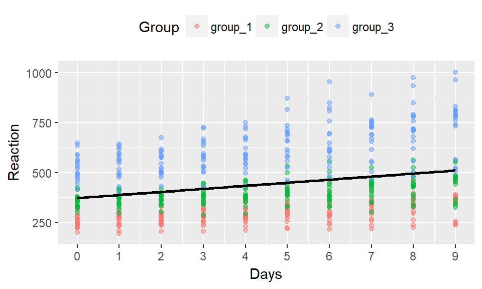

But we clearly have 3 distinct groups of people here…

## Fixed and Random Effects

### Random Intercepts

```r
# fit random intercepts model
intercepts_model <- lmer(Reaction ~ Days + (1 | Group), data = sleep_groups)
```

Same structure as before, only with `lmer()` and we define a random intercept (1) for each group in our data; `+ (1 | Group)`.

## Fixed and Random Effects

### Random Intercepts

```r
# see group coefficients
model_coefs <- coef(intercepts_model)$Group %>%
  rename(Intercept = `(Intercept)`, Slope = Days) %>%
  rownames_to_column("Group")

# see coefficients
model_coefs
```

```
##     Group Intercept    Slope
## 1 group_1  229.3394 15.40385
## 2 group_2  329.0908 15.40385
## 3 group_3  556.6432 15.40385
```

## Fixed and Random Effects

### Random Intercepts

How do these coefficients look?

We pick random intercepts if we think only the baseline will differ.

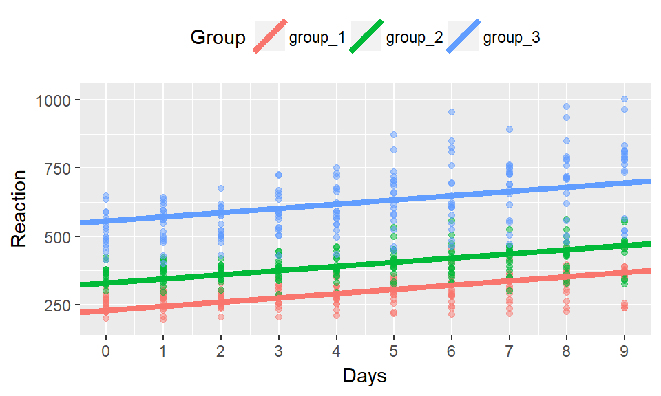

## Fixed and Random Effects

### Random Slopes

Now we refit the model with random slopes only, see slopes (i.e. Days) by Group. 0 means no random intercepts.

```r
# fit random intercepts model
model <- lmer(Reaction ~ Days + (0 + Days | Group), data = sleep_groups)
```

## Fixed and Random Effects

### Random Slopes

Have a look at the coefficients, how do they compare?

```r
# see group coefficients
model_coefs <- coef(model)$Group %>%
  rename(Intercept = `(Intercept)`, Slope = Days) %>%
  rownames_to_column("Group")

model_coefs
```

```
##     Group Intercept     Slope
## 1 group_1  371.6912 -8.479087
## 2 group_2  371.6912  7.249332
## 3 group_3  371.6912 47.441298
```

## Fixed and Random Effects

### Random Slopes

How do these random slopes look? Compare that with the intercepts. Here we expect only rates to differ, not baseline.

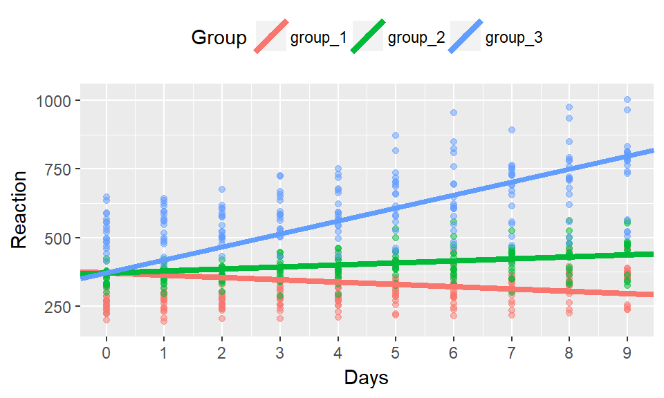

## Fixed and Random Effects

### Random Intercepts & Slopes

Here, we specify random intercepts (1) and Slopes (Days) by Group.

```r
# fit random intercepts model
model <- lmer(Reaction ~ Days + (1 + Days | Group), data = sleep_groups)
```

## Fixed and Random Effects

### Random Intercepts & Slopes

Have a look at the coefficients. How do they compare?

```r
# see group coefficients
model_coefs <- coef(model)$Group %>%
  rename(Intercept = `(Intercept)`, Slope = Days) %>%
  rownames_to_column("Group")

model_coefs
```

```
##     Group Intercept     Slope
## 1 group_1  256.4992  9.456212
## 2 group_2  344.2956 11.894381
## 3 group_3  514.2786 24.860950
```

## Fixed and Random Effects

### Random Intercepts & Slopes

How do these intercepts and slopes look? Here, we expect different baseline scores, and different rates across the groups.

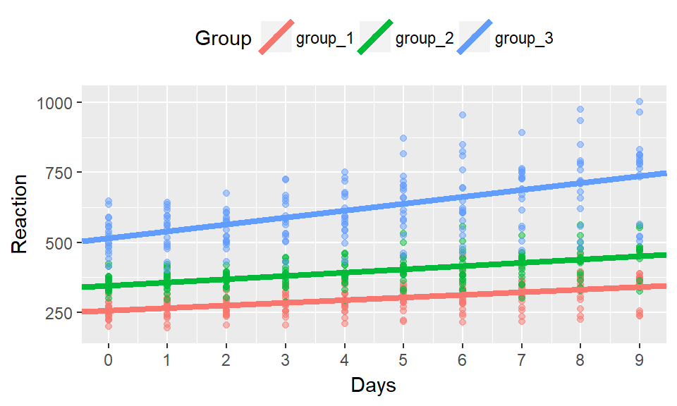

## Specifying Your Random Effects

## Specifying Your Random Effects

- Keep it maximal: include all intercepts and slopes justified by the design; fit intercepts, slopes, and correlations and only reduce where models don't converge – good protection against type-I error.
- Assess model fits: include only terms that improve model fit – balance type-I error and power.
- Most importantly, make sure your structure matches the design!

## Crossed Random Effects

Crossed random effects of condition if:

- observations can be assigned to more than one random effect simulataneously
- observations are a unique combination of random effects, which co-occur
- all combinations of random effects are seen in the data

```
## # A tibble: 6 x 4
##   Subject  Item Condition Response
##     <int> <int> <chr>        <dbl>
## 1       1     1 A             84.5
## 2       2     1 B            101
## 3       1     2 A             79.9
## 4       2     2 B             97.7
## 5       1     3 B             83.8
## 6       2     3 A             87.4
```

Model with crossed random effects of subjects and items:

```r
lmer(Response ~ Condition + (1 | Subject) + (1 | Item), data = crossed_data)
```

## Nested Random Effects

Nested if:

- they are not crossed
- participants take part in one condition of a factor, in another condition of a factor.
- all combinations of the random effects are not seen in the data

Hence, unique observations are a combination of factors: e.g. students within classes within schools.

```r
nested_data <- tibble(
  Student = seq(1:10),
  Class = rep(seq(1:5), 2),
  School = c(rep(1, 5), rep(2, 5)),
  Intervention = rep(c("yes", "no"), 5),
  Outcome = rnorm(n = 10, mean = 200, sd = 20)
)
```

## Nested Random Effects

```r
nested_data
```

```
## # A tibble: 10 x 5
##    Student Class School Intervention Outcome
##      <int> <int>  <dbl> <chr>          <dbl>
##  1       1     1   1.00 yes              200
##  2       2     2   1.00 no               171
##  3       3     3   1.00 yes              200
##  4       4     4   1.00 no               218
##  5       5     5   1.00 yes              233
##  6       6     1   2.00 no               220
##  7       7     2   2.00 yes              217
##  8       8     3   2.00 no               200
##  9       9     4   2.00 yes              168
## 10      10     5   2.00 no               194
```

Model with nested random effects of students within classes within schools:

```r
lmer(Outcome ~ Intervention + (1 | School/Class/Student), data = nested_data)
```

## Nested Random Effects

Check if you have nested random effects by making a unique combination of the levels:

```r
nested_data$Class_ID <- paste(nested_data$School, nested_data$Class, sep = "_")
head(nested_data)
```

```
## # A tibble: 6 x 6
##   Student Class School Intervention Outcome Class_ID
##     <int> <int>  <dbl> <chr>          <dbl> <chr>
## 1       1     1   1.00 yes              200 1_1
## 2       2     2   1.00 no               171 1_2
## 3       3     3   1.00 yes              200 1_3
## 4       4     4   1.00 no               218 1_4
## 5       5     5   1.00 yes              233 1_5
## 6       6     1   2.00 no               220 2_1
```

Now classes are clearly unique to schools, so students should be nested within both.

## Exploring Different Random Effects Structres

Within subjects design, participants see half of the items in our study in one condition, half in another condition. Let's take the `crossed_data` example from before.

```r
crossed_data
```

```
## # A tibble: 10 x 4
##    Subject  Item Condition Response
##      <int> <int> <chr>        <dbl>
##  1       1     1 A             84.5
##  2       2     1 B            101
##  3       1     2 A             79.9
##  4       2     2 B             97.7
##  5       1     3 B             83.8
##  6       2     3 A             87.4
##  7       1     4 B             97.9
##  8       2     4 A            100
##  9       1     5 B            115
## 10       2     5 A             91.6
```

## Exploring Different Random Effects Structres

Random intercepts and slopes for subjects and items by adding condition (our slope term; change in response for 1 unit of condition) to the left of each term (along with the random intercept).

```r
lmer(
  Outcome ~ Condition +
    (1 + Condition | Subject) +
    (1 + Condition | Item),
  data = data
  )
```

## Exploring Different Random Effects Structres

What if they took part in several blocks of study?

If same items within block, add to both subjects and items.

```r
# same items within each block
lmer(
  Outcome ~ Condition + Block +
    (1 + Condition + Block | Subject) +
    (1 + Condition + Block | Item),
  data = data
  )
```

## Exploring Different Random Effects Structres

If new items, add only to subjects (as their performance changes; items cannot).

```r
# new items within each block
lmer(
  Outcome ~ Condition + Block +
    (1 + Condition + Block | Subject) +
    (1 + Condition | Item),
  data = data
  )
```

## Exploring Different Random Effects Structures

For any between subjects conditions, you cannot have random slopes for subject (as they only see one condition). But you can for item.

```r
lmer(
  Outcome ~ Condition +
    (1 | Subject) +
    (1 + Condition | Item),
  data = data
  )
```

## Exploring Different Random Effects Structures

If we want an interaction between factors, we simply use an asterisk bto define our interactions, e.g.:

```r
lmer(
  Outcome ~ factor_A * factor_B +
    (1 + factor_A * factor_B | Subject) +
    (1 + factor_A * factor_B | Item),
  data = data
  )
```

## Partial Pooling

## Exploring Pooling of Data

Partial pooling is one of the biggest advantages of mixed effects models. What is it? Let's explore it with plots. (This follows TJ Mahr's example online; see the web book for details.)

We'll use the sleepstudy data set with added subjects with missing data.

```r
sleep_study <- read_csv("inputs/sleep_study_with_sim.csv")
```

## Complete Pooling of Data

All data put together to make one slope and intercept. Typical linear model.

```r
# fit model
complete_pooling <- lm(Reaction ~ Days, data = sleep_study)

# tidy up and print model coefficients
complete_pooling_coefs <- coef(complete_pooling)
complete_pooling_coefs
```

```
## (Intercept)        Days
##   252.09397    10.03451
```

## Complete Pooling of Data

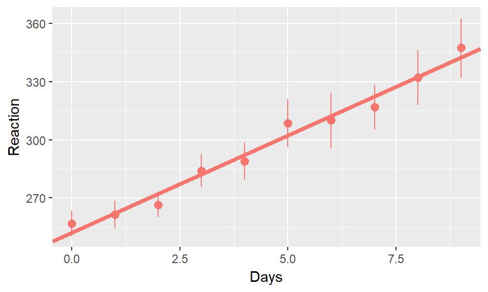

That fits the overall performance well. But what about on the individual level? How well does it explain each participant's response?

## Complete Pooling of Data

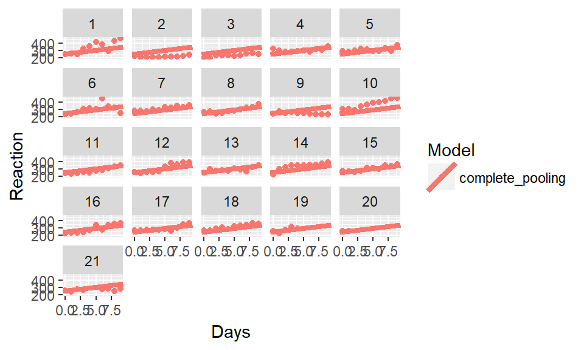

## Complete Pooling of Data

```r
# fit the model
no_pooling <- lmer(Reaction ~ Days | Subject, data = sleep_study)

# extract and view model coefficients
no_pooling_coefs <- coef(no_pooling)$Subject %>%
  rename(Intercept = `(Intercept)`, Slope = Days)
head(no_pooling_coefs)
```

```
##         Slope Intercept
## 1 20.60345661  249.4094
## 2 -0.02555511  219.9898
## 3  3.66034762  219.0878
## 4  4.24611744  281.1159
## 5  6.27933617  278.4035
## 6  9.56681539  263.1536
```

## Complete Pooling

Take a look at participant 20. Do you think the no pooling model is any better than the complete pooling model? What about participant 2?

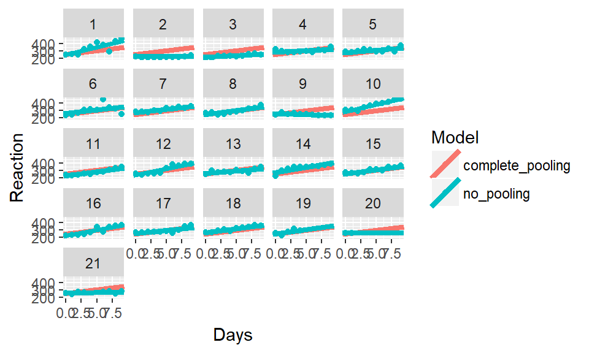

## Partial Pooling

This is where lme4 shines. We fit random intercepts and slopes for each participant, but their fits are pulled towards the mean (shrinkage).

This is great when we have missing or extreme data. Fit this with a mixed effects model with random intercepts and slopes.

```r
partial_pooling <- lmer(Reaction ~ Days + (Days | Subject), data = sleep_study)
```

## Partial Pooling

Next, we can plot the different models against one another to see what happens.

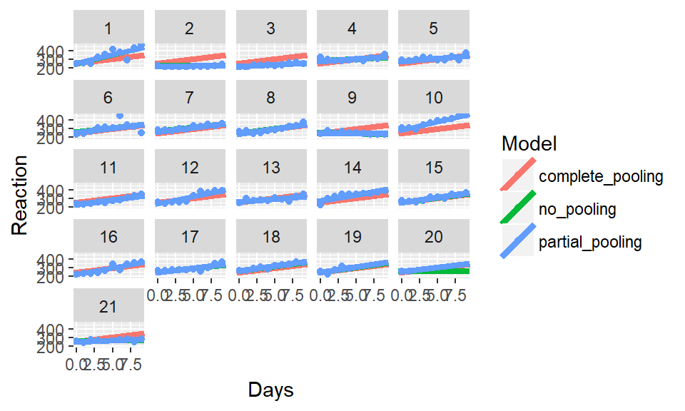

## Partial Pooling

As with TJ's article, we'll also zoom in to some of these participants too see what happens.

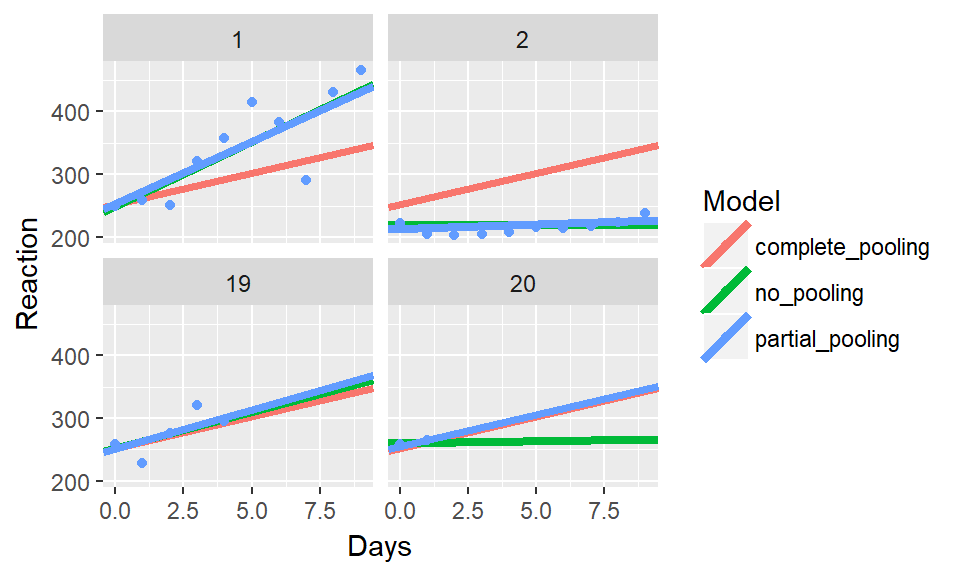

Models largely fit the no pooling model, but are pulled slightly to the mean – especially so with extreme/missing data.

## Let's Fit Some Models!

## Interpreting Mixed Effects Model Output

We'll use the `lexdec` dataset from the `languageR` library. Load this by loading the library and running the code below to subset to columns.

```r
library(languageR)
lex_dec <- as.tibble(lexdec) %>%
  select(Subject, Trial, Word, NativeLanguage, RT)
```

## Interpreting Mixed Effects Model Output

We'll centre the language factor as we want to do model comparisons/change our intercept interpretation.

```r
# centre the factor
lex_dec$lang_c <- (lex_dec$NativeLanguage == "English") -
  mean(lex_dec$NativeLanguage == "English")

# see the result
head(lex_dec)
```

```
## # A tibble: 6 x 6
##   Subject Trial Word       NativeLanguage    RT lang_c
##   <fct>   <int> <fct>      <fct>          <dbl>  <dbl>
## 1 A1         23 owl        English         6.34  0.429
## 2 A1         27 mole       English         6.31  0.429
## 3 A1         29 cherry     English         6.35  0.429
## 4 A1         30 pear       English         6.19  0.429
## 5 A1         32 dog        English         6.03  0.429
## 6 A1         33 blackberry English         6.18  0.429
```

## Interpreting Mixed Effects Model Output

Fit a random intercepts model. What does the output mean? REML better for random variance than ML (which is better for estimating fixed parameters).

```r
lexdec_mod <- lmer(
  RT ~ lang_c +
    (1 | Subject) + (1 | Word),
  data = lex_dec, REML = F
  )
```

## Interpreting Mixed Effects Model Output

```r
summary(lexdec_mod)
```

```
## Linear mixed model fit by maximum likelihood  ['lmerMod']
## Formula: RT ~ lang_c + (1 | Subject) + (1 | Word)
##    Data: lex_dec
##
##      AIC      BIC   logLik deviance df.resid
##   -900.1   -873.0    455.1   -910.1     1654
##
## Scaled residuals:
##     Min      1Q  Median      3Q     Max
## -2.3600 -0.6142 -0.1196  0.4614  5.9658
##
## Random effects:
##  Groups   Name        Variance Std.Dev.
##  Word     (Intercept) 0.005896 0.07678
##  Subject  (Intercept) 0.016742 0.12939
##  Residual             0.029842 0.17275
## Number of obs: 1659, groups:  Word, 79; Subject, 21
##
## Fixed effects:
##             Estimate Std. Error t value
## (Intercept)  6.38509    0.02983   214.1
## lang_c      -0.15582    0.05770    -2.7
##
## Correlation of Fixed Effects:
##        (Intr)
## lang_c 0.000
```

## Interpreting Mixed Effects Model Output

If you just want fixed effects, do:

```r
coef(summary(lexdec_mod))
```

```r
broom::tidy(lexdec_mod)
```

```
##                      term    estimate  std.error  statistic    group
## 1             (Intercept)  6.38508974 0.02983012 214.048401    fixed
## 2                  lang_c -0.15582119 0.05769542  -2.700755    fixed
## 3     sd_(Intercept).Word  0.07678358         NA         NA     Word
## 4  sd_(Intercept).Subject  0.12938933         NA         NA  Subject
## 5 sd_Observation.Residual  0.17274751         NA         NA Residual
```

## Calculating p-values for Parameter Estimates

No *p*-values. Why? How do we calculate them? Different Options:

- Kenward-Roger or Satterthwaite approximations by the **lmerTest** and **afex** packages
- Model comparisons
- Calculate manually using the normal approximation (*t*-value treated as a *z*-value)

Different discussions and explorations of why to pick different methods. The last is anti-conservative, but not terribly so with large sample sizes.

## Using the Normal Approximation

Normal approximation method: find *p*-value that matches the absolute (non-signed) *t*-value in the normal distribution. Subtract from 1 to get the probability of a *t*-value exceeding what we have. Multiply by 2 to get a two-tailed *p*-value.

```r
lexdec_mod %>%
  broom::tidy("fixed") %>%
  mutate(p_value = 2*(1 - pnorm(abs(statistic))))
```

```
##          term   estimate  std.error  statistic     p_value
## 1 (Intercept)  6.3850897 0.02983012 214.048401 0.000000000
## 2      lang_c -0.1558212 0.05769542  -2.700755 0.006918227
```

## Using Model Selection

Logic: See whether adding a term improves model fit over a reduced model without the term. If so, it improves model fit, and hence matters for your data!

Fit reduced model without the term we care about

```r
lexdec_mod_reduced <- lmer(
  RT ~ 1 +
    (1 | Subject) + (1 | Word),
  data = lex_dec, REML = F
  )
```

Use `anova()` to compare model fits. Must use ML and not REML to fit models. Check change in log-likelihood or improvement to model fit. **Must** add incrementally, 1 df at a time so you know that term is what is being assessed.

## Using Model Selection

```r
anova(lexdec_mod, lexdec_mod_reduced)
```

```
## Data: lex_dec
## Models:
## lexdec_mod_reduced: RT ~ 1 + (1 | Subject) + (1 | Word)
## lexdec_mod: RT ~ lang_c + (1 | Subject) + (1 | Word)
##                    Df     AIC     BIC logLik deviance  Chisq Chi Df
## lexdec_mod_reduced  4 -895.86 -874.20 451.93  -903.86
## lexdec_mod          5 -900.12 -873.05 455.06  -910.12 6.2605      1
##                    Pr(>Chisq)
## lexdec_mod_reduced
## lexdec_mod            0.01235 *
## ---
## Signif. codes:  0 '***' 0.001 '**' 0.01 '*' 0.05 '.' 0.1 ' ' 1
```

\(\chi^2(1) = 6.261, p = 0.012\).

## Model Selection for Choosing Random Effects Structures

Model with and without the intercept/slope covariance. Compare random intercepts, to intercepts and slope on word, and intercepts, slope on word, and covariance between intercept and slope on word.

```r
lexdec_slope <- lmer(RT ~ lang_c + (1 | Subject) + (lang_c || Word),
                     data = lex_dec, REML = F)

lexdec_slope_cov <- lmer(RT ~ lang_c + (1 | Subject) + (lang_c | Word),
                         data = lex_dec, REML = F)
```

## Model Selection for Choosing Random Effects Structures

```r
anova(lexdec_mod, lexdec_slope, lexdec_slope_cov)
```

```
## Data: lex_dec
## Models:
## lexdec_mod: RT ~ lang_c + (1 | Subject) + (1 | Word)
## lexdec_slope: RT ~ lang_c + (1 | Subject) + ((1 | Word) + (0 + lang_c | Word))
## lexdec_slope_cov: RT ~ lang_c + (1 | Subject) + (lang_c | Word)
##                  Df     AIC     BIC logLik deviance   Chisq Chi Df
## lexdec_mod        5 -900.12 -873.05 455.06  -910.12
## lexdec_slope      6 -903.05 -870.57 457.53  -915.05  4.9348      1
## lexdec_slope_cov  7 -921.40 -883.51 467.70  -935.40 20.3514      1
##                  Pr(>Chisq)
## lexdec_mod
## lexdec_slope        0.02632 *
## lexdec_slope_cov  6.445e-06 ***
## ---
## Signif. codes:  0 '***' 0.001 '**' 0.01 '*' 0.05 '.' 0.1 ' ' 1
```

## How do the Covariance/No-Covariance Models Differ?

Get the variance and correlation components:

```r
VarCorr(lexdec_slope, comp="Variance")
```

```
##  Groups   Name        Std.Dev.
##  Word     lang_c      0.048487
##  Word.1   (Intercept) 0.076971
##  Subject  (Intercept) 0.129448
##  Residual             0.170988
```

## How do the Covariance/No-Covariance Models Differ?

This explains data best. See correlation between random factors.

```r
VarCorr(lexdec_slope_cov, comp="Variance")
```

```
##  Groups   Name        Std.Dev. Corr
##  Word     (Intercept) 0.076968
##           lang_c      0.048463 -0.984
##  Subject  (Intercept) 0.129444
##  Residual             0.170988
```

## Final Remarks

## Failure to Converge: What Should I Do?

Often due to not having enough data/noisy data to fit with desired model. Maximal models often don't converge. We run out of dfs to estimate parameters.

1. Try a different optimiser.

```r
nelder_mod <- lmer(
  RT ~ lang_c + (1 | Subject) + (lang_c | Word),
  data = lex_dec, REML = F,
  control = lmerControl(optimizer = "Nelder_Mead")
  )
boby_mod <- lmer(
  RT ~ lang_c + (1 | Subject) + (lang_c | Word),
  data = lex_dec, REML = F,
  control = lmerControl(optimizer = "bobyqa")
     )
```

## Failure to Converge: What Should I Do?

Why items first? Typically less variance because we construct them carefully.

## Test Assumptions

- Linearity: Linear models need linearly related data.
- Independence: Model must specify dependencies (e.g. multiple observations per subject) or it won't fit properly.
- Normal Distribution of Random Coefficients: random coefficients are assumed to be normally distributed around the model.
- Multicollinearity: One predictor can be predicted by others in the model. Centering your predictors can help with problems of multicollinearity.
- Homoscedasticity: The error term in your model should be the same across all of your variables. Use Levene's test/residual vs. fitted values plot.
- Outliers: Large outliers will skew your data. Make sure you have a principled decision for excluding data.

## Generalised Mixed Effects Models

What if data don't follow normal distribution? Use a generalised mixed effects model with a different distribution type, e.g. binomial data and logistic fit.

```r
glmer(
  DV_binom ~ # binomial dependent variable
    A * B + # fixed effects
    (A * B | subject) + (A * B | item), # random effects
  family = binomial, # family: type of distribution
  data = data,
  glmerControl(optimizer = "bobyqa") # options; notice glmerControl (not lmer)
  )
```

- Notice only differences: **g**lmer(), family of distribution, **g**lmerControl.
- We get *p*-values automatically here!
- Parameter estimates represent log likelihoods

## Generalised Mixed Effects Models

What about proportions? DV as proportion…

```r
glmer(
  DV_prop ~ # dependent variable as a proportion
    A * B + # fixed effects
    (A * B | subject) + (A * B | item), # random effects
  family = binomial, # family: type of distribution
  weights = N_observations, # number of observations making up the proportion
  data = data,
  glmerControl(optimizer = "bobyqa")# options; notice glmerControl (not lmer)
  )
```

## Generalised Mixed Effects Models

What about proportions? DV as successes divided by observations…

```r
glmer(
  DV_successes/N_observations ~ # calculate proportion
    A * B + # fixed effects
    (A * B | subject) + (A * B | item), # random effects
  family = binomial, # family: type of distribution
  weights = N_observations, # number of observations making up the proportion
  data = data,
  glmerControl(optimizer = "bobyqa") # options; notice glmerControl (not lmer)
  )
```

## A Note on Power, Effect Sizes, and Pairwise Comparisons

- Power is difficult to compute. Need to use simulation, **simr** package helps with this. But often difficult to think in terms of random effects and covariance matrices.
- Standardised effect sizes often not reported, but: `r2beta()` function from **r2glmm**, or `r.squaredGLMM()` from **MuMIn** to get overall model effect size/parameter estimates effect sizes.
- Pairwise comparisons: Just like with linear models. Option 1 - subset data and it model on subsets of factors for exploring simple effects. Here, you need to manually adjust *p*-values for multiple comparisons. Or, use `glht()` function from the **multcomp** package if all parameter estimates are in the model and you just want all comparisons.